# peppwR Example Application: Supplementary Material

Dan MacLean

## 1. Setup

```r
library(peppwR)
library(dplyr)
library(tidyr)
library(ggplot2)
library(cowplot)
library(fitdistrplus)

set.seed(42)  # Reproducibility
```

## 2. Simulate Phosphoproteomics Pilot Data

### 2.1 Define peptide parameters

We simulate 500 peptides with heterogeneous gamma distribution parameters:

- **Shape**: uniform(1.5, 5) — captures low-to-high abundance peptides
- **Rate**: uniform(0.05, 0.2) — captures variance heterogeneity
- Results in mean abundances ranging ~7.5 to 100 (realistic intensity range)

```r
n_peptides <- 500
n_pilot <- 6  # samples per condition in pilot

peptide_params <- tibble(
  peptide = paste0("pep_", sprintf("%04d", 1:n_peptides)),
  shape = runif(n_peptides, min = 1.5, max = 5),
  rate = runif(n_peptides, min = 0.05, max = 0.2)
) |>
  mutate(
    theoretical_mean = shape / rate,
    theoretical_cv = 1 / sqrt(shape)  # CV for gamma
  )

# Summary of parameter ranges
peptide_params |>
  summarise(
    across(c(shape, rate, theoretical_mean, theoretical_cv),
           list(min = min, median = median, max = max))
  ) |>
  pivot_longer(everything(), names_to = "stat", values_to = "value") |>
  print(n = 20)
```

```
## # A tibble: 12 × 2
##    stat                      value
##    <chr>                     <dbl>
##  1 shape_min                1.50
##  2 shape_median             3.18
##  3 shape_max                4.99
##  4 rate_min                 0.0501
##  5 rate_median              0.122
##  6 rate_max                 0.200
##  7 theoretical_mean_min     8.34
##  8 theoretical_mean_median 25.8
##  9 theoretical_mean_max    93.7
## 10 theoretical_cv_min       0.448
## 11 theoretical_cv_median    0.561
## 12 theoretical_cv_max       0.816
```

### 2.2 Generate abundance values

```r
pilot_data <- peptide_params |>
  rowwise() |>
  mutate(
    abundance = list(rgamma(n_pilot, shape = shape, rate = rate))
  ) |>
  ungroup() |>
  dplyr::select(peptide, abundance) |>
  unnest(abundance) |>
  mutate(
    sample = rep(paste0("S", 1:n_pilot), n_peptides),
    condition = "control"
  )

cat("Pilot data dimensions:", nrow(pilot_data), "rows x", ncol(pilot_data), "columns\n")
```

```
## Pilot data dimensions: 3000 rows x 4 columns
```

```r
head(pilot_data)
```

```
## # A tibble: 6 × 4
##   peptide  abundance sample condition
##   <chr>        <dbl> <chr>  <chr>
## 1 pep_0001      93.3 S1     control
## 2 pep_0001      89.2 S2     control
## 3 pep_0001      59.5 S3     control
## 4 pep_0001      77.8 S4     control
## 5 pep_0001      88.1 S5     control
## 6 pep_0001      64.5 S6     control
```

### 2.3 Introduce MNAR missingness

We introduce missing-not-at-random (MNAR) patterns typical of mass spectrometry data:

- Target ~15% overall missingness
- Probability of NA inversely related to abundance (rank-based)
- Low-abundance peptides (bottom quartile) have up to 40% missingness
- High-abundance peptides have near-zero missingness

```r
# Calculate per-peptide mean abundance and rank
peptide_means <- pilot_data |>
  group_by(peptide) |>
  summarise(mean_abundance = mean(abundance), .groups = "drop") |>
  mutate(
    abundance_rank = rank(mean_abundance) / n(),
    # Low abundance (rank near 0) = higher missingness; high abundance = near zero
    p_missing = pmax(0, 0.4 * (1 - abundance_rank)^2)
  )

pilot_data <- pilot_data |>
  left_join(peptide_means, by = "peptide") |>
  mutate(
    is_missing = runif(n()) < p_missing,
    abundance = if_else(is_missing, NA_real_, abundance)
  ) |>
  dplyr::select(peptide, sample, condition, abundance)

# Report missingness
overall_missing <- mean(is.na(pilot_data$abundance))
cat("Overall missingness rate:", round(overall_missing * 100, 1), "%\n")
```

```
## Overall missingness rate: 12.7 %
```

```r
# Calculate missingness rate per peptide
missingness_by_peptide <- pilot_data |>
  group_by(peptide) |>
  summarise(
    miss_rate = mean(is.na(abundance)),
    mean_abundance = mean(abundance, na.rm = TRUE),
    .groups = "drop"
  )

# Correlation between abundance and missingness
cor_test <- cor.test(missingness_by_peptide$mean_abundance,
                     missingness_by_peptide$miss_rate,
                     use = "complete.obs")
cat("Correlation (abundance vs missingness):", round(cor_test$estimate, 3),
    "(p =", format.pval(cor_test$p.value, digits = 2), ")\n")
```

```
## Correlation (abundance vs missingness): -0.572 (p = <2e-16 )
```

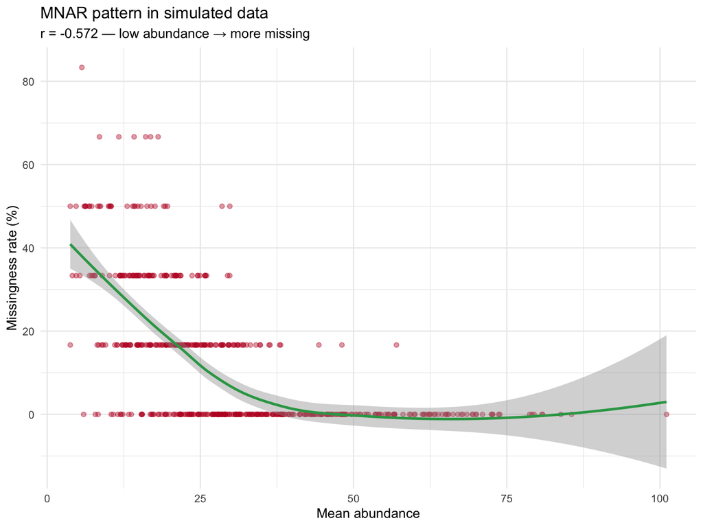

MNAR pattern: low-abundance peptides have higher missingness rates

```r
# Plot MNAR pattern
ggplot(missingness_by_peptide, aes(x = mean_abundance, y = miss_rate * 100)) +
  geom_point(alpha = 0.4, color = "#BD0026") +
  geom_smooth(method = "loess", se = TRUE, color = "#31A354") +
  labs(
    x = "Mean abundance",
    y = "Missingness rate (%)",
    title = "MNAR pattern in simulated data",
    subtitle = paste0("r = ", round(cor_test$estimate, 3), " — low abundance → more missing")
  ) +
  theme_minimal()
```

## 3. Distribution Fitting

```r
fits <- fit_distributions(
  pilot_data,
  id = "peptide",
  group = "condition",
  value = "abundance",
  distributions = "continuous"
)

print(fits)
```

```
## peppwr_fits object
## ------------------
## 500 peptides fitted
##
## Best fit distribution counts:
##   Gamma: 85
##   Inverse Gaussian: 25
##   InvGamma: 3
##   Loggamma: 3
##   Normal: 38
##   Pareto: 242
##   Skew Normal: 104
##
## Missingness: 381/3000 values NA (12.7%)
## Peptides with missing data: 229
##
## MNAR detection (abundance vs missingness):
##   Correlation: r = -0.48 (p = 1.1e-14)
##   Moderate evidence of MNAR: low-abundance peptides have more missing values (p = 1.1e-14)
```

```r
summary(fits)
```

```
## Summary of peppwr_fits
## ======================
##
## Peptides fitted: 500
## Failed fits: 0 (0.0%)
##
## Best distribution counts:
##   Gamma: 85
##   Inverse Gaussian: 25
##   InvGamma: 3
##   Loggamma: 3
##   Normal: 38
##   Pareto: 242
##   Skew Normal: 104
##
## Fit statistics:
##   AIC range: [6.4, Inf]
##   AIC median: 46.4
##   LogLik range: [-Inf, -1.2]
##   LogLik median: -21.1
```

### 3.1 Dataset-level MNAR Detection

peppwR automatically detects MNAR (missing-not-at-random) patterns by correlating mean abundance with missingness rate **across peptides**. A negative correlation indicates low-abundance peptides are systematically more likely to be missing—the hallmark of detection-limit-driven MNAR in mass spectrometry.

```r
# Between-peptide MNAR detection
fits$dataset_mnar
```

```
## $correlation
## [1] -0.4813178
##
## $p_value
## [1] 1.108704e-14
##
## $n_peptides
## [1] 229
##
## $interpretation
## [1] "Moderate evidence of MNAR: low-abundance peptides have more missing values (p = 1.1e-14)"
```

This dataset-level metric is statistically robust because it leverages information across hundreds of peptides, unlike within-peptide MNAR detection which would require many replicates per peptide.

## 4. Primary Power Analysis

### 4.1 Find required sample size

In per-peptide mode, peppwR calculates power separately for each peptide based on its fitted distribution. Because peptides differ in abundance and variance, they achieve different power levels at the same sample size.

The key metric is: **what proportion of peptides achieve the target power (e.g., 80%) at a given sample size?**

We set two thresholds: - `target_power = 0.8`: each peptide needs 80% power to be considered “adequately powered” - `proportion_threshold = 0.8`: we want 80% of peptides to meet that criterion

The question becomes: **at what N do 80% of peptides individually achieve 80% power?**

```r
result_primary <- power_analysis(
  fits,
  effect_size = 2,

  target_power = 0.8,
  proportion_threshold = 0.8,
  find = "sample_size",
  test = "wilcoxon",
  n_sim = 1000
)

print(result_primary)
```

```
## peppwr_power analysis
## ---------------------
## Mode: per_peptide
##
## Recommended sample size: N=20 per group
## Target power: 80%
## Effect size: 2.00-fold
##
## Statistical test: wilcoxon
## Significance level: 0.05
```

**Primary result**: N = 20 per group required.

## 5. Comparison 1: Per-Peptide vs Homogeneous

### 5.1 Homogeneous (aggregate) approach

Generic power tools pool all data and assume uniform variance across peptides.

```r
# Pool all non-NA values
pooled_data <- pilot_data |>
  filter(!is.na(abundance))

# Fit single gamma to pooled data
pooled_fit <- fitdistrplus::fitdist(pooled_data$abundance, "gamma")
pooled_params <- as.list(pooled_fit$estimate)

cat("Pooled gamma parameters:\n")
```

```
## Pooled gamma parameters:
```

```r
cat("  shape =", round(pooled_params$shape, 3), "\n")
```

```
##   shape = 1.787
```

```r
cat("  rate =", round(pooled_params$rate, 3), "\n")
```

```
##   rate = 0.056
```

```r
# Power analysis with homogeneous assumption
result_homogeneous <- power_analysis(
  "gamma",
  params = pooled_params,
  effect_size = 2,
  target_power = 0.8,
  find = "sample_size",
  test = "wilcoxon",
  n_sim = 1000
)

print(result_homogeneous)
```

```
## peppwr_power analysis
## ---------------------
## Mode: aggregate
##
## Recommended sample size: N=25 per group
## Target power: 80%
## Effect size: 2.00-fold
##
## Statistical test: wilcoxon
## Significance level: 0.05
```

### 5.2 Comparison summary

```r
comparison_1 <- tibble(
  Approach = c("Homogeneous (pooled)", "Per-peptide (peppwR)"),
  `Required N` = c(result_homogeneous$answer, result_primary$answer),
  Description = c(
    "Single distribution fitted to pooled data",
    "Distribution fitted per peptide, 80% threshold"
  )
)

pct_more <- round((result_primary$answer - result_homogeneous$answer) /
                    result_homogeneous$answer * 100)

knitr::kable(comparison_1, caption = "Sample size estimates by approach")
```

Sample size estimates by approach

| Approach | Required N | Description |
| --- | --- | --- |
| Homogeneous (pooled) | 25 | Single distribution fitted to pooled data |
| Per-peptide (peppwR) | 20 | Distribution fitted per peptide, 80% threshold |

## 6. Comparison 2: Statistical Test Choice

### 6.1 Bayes factor t-test

```r
result_bayes <- power_analysis(
  fits,
  effect_size = 2,
  target_power = 0.8,
  proportion_threshold = 0.8,
  find = "sample_size",
  test = "bayes_t",
  n_sim = 1000
)

print(result_bayes)
```

```
## peppwr_power analysis
## ---------------------
## Mode: per_peptide
##
## Recommended sample size: N=10 per group
## Target power: 80%
## Effect size: 2.00-fold
##
## Statistical test: bayes_t
## Decision threshold: BF > 3 (substantial evidence)
```

### 6.2 Comparison summary

```r
comparison_2 <- tibble(
  Test = c("Wilcoxon rank-sum", "Bayes factor t-test"),
  `Required N` = c(result_primary$answer, result_bayes$answer),
  Characteristics = c(
    "Non-parametric, conservative, no distributional assumptions",
    "Parametric Bayesian, more efficient when assumptions hold"
  )
)

efficiency_gain <- round((result_primary$answer - result_bayes$answer) /
                           result_primary$answer * 100)

knitr::kable(comparison_2, caption = "Sample size estimates by statistical test")
```

Sample size estimates by statistical test

| Test | Required N | Characteristics |
| --- | --- | --- |
| Wilcoxon rank-sum | 20 | Non-parametric, conservative, no distributional assumptions |
| Bayes factor t-test | 10 | Parametric Bayesian, more efficient when assumptions hold |

**Key finding**: Bayes factor t-test is **50% more efficient** than Wilcoxon when parametric assumptions hold.

## 7. Figure 1 Generation

### 7.1 Panel A: Workflow diagram

```r
library(DiagrammeR)

workflow_graph <- grViz("
  digraph workflow {
    graph [rankdir=TB, bgcolor='transparent', fontname='Helvetica', nodesep=0.4, ranksep=0.5]
    node [shape=box, style='rounded,filled', fontname='Helvetica', fontsize=14,
          width=2.2, height=0.6, penwidth=2]
    edge [fontname='Helvetica', fontsize=11, penwidth=1.5]

    # Input
    pilot [label='Pilot Data', fillcolor='#FEE5D9', color='#BD0026']

    # Functions
    fit [label='fit_distributions()', fillcolor='#FCBBA1', color='#BD0026', fontname='Courier']
    power [label='power_analysis()', fillcolor='#FC9272', color='#BD0026', fontname='Courier']

    # Output
    result [label='Sample Size | Power | Effect Size', fillcolor='#FEB24C', color='#BD0026']

    # Edges
    pilot -> fit
    fit -> power [label='fits']
    power -> result
  }
")

# Convert to ggplot-compatible object
panel_a <- ggdraw() +
  draw_image(
    DiagrammeRsvg::export_svg(workflow_graph) |>
      charToRaw() |>
      rsvg::rsvg_png(width = 1200, height = 1400),
    scale = 0.95
  ) +
  draw_label("A) peppwR workflow", x = 0.5, y = 0.98, size = 10, fontface = "bold")
```

### 7.2 Panel B: Power heterogeneity histogram

```r
# Run power analysis at fixed N=6 to get per-peptide power
result_n6 <- power_analysis(
  fits,
  effect_size = 2,
  n_per_group = 6,
  find = "power",
  test = "wilcoxon",
  n_sim = 1000
)
```

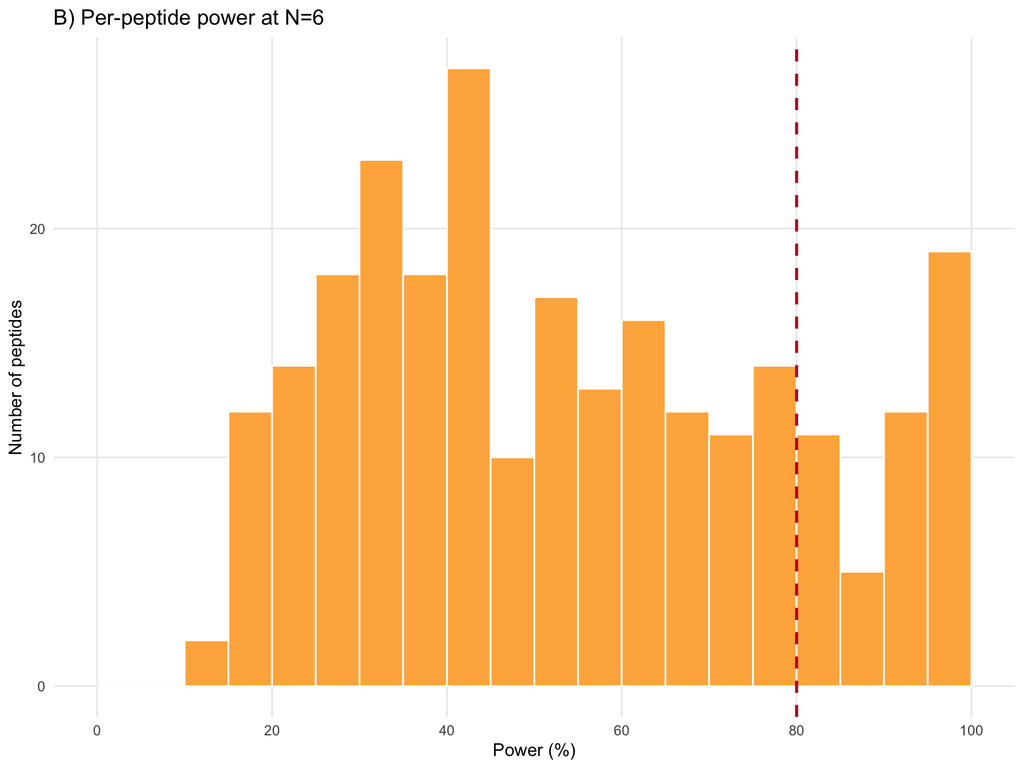

```r
# Extract per-peptide power
power_at_n6 <- data.frame(power = result_n6$simulations$peptide_power)

panel_b <- ggplot(power_at_n6, aes(x = power * 100)) +
  geom_histogram(
    binwidth = 5,
    fill = "#FEB24C",
    color = "white",
    boundary = 0
  ) +
  geom_vline(xintercept = 80, linetype = "dashed", color = "#BD0026", linewidth = 0.8) +
  scale_x_continuous(limits = c(0, 100), breaks = seq(0, 100, 20)) +
  labs(
    x = "Power (%)",
    y = "Number of peptides",
    title = "B) Per-peptide power at N=6"
  ) +
  theme_minimal(base_size = 10) +
  theme(panel.grid.minor = element_blank())

panel_b
```

**Observation**: Power varies dramatically across peptides — this heterogeneity is why per-peptide analysis matters.

### 7.3 Panel C: Power curve with test comparison

```r
# Extract power curves from find="sample_size" results
curve_wilcoxon <- result_primary$simulations$power_curve |>
  mutate(pct_powered = proportion_powered * 100, test = "Wilcoxon")

curve_bayes <- result_bayes$simulations$power_curve |>
  mutate(pct_powered = proportion_powered * 100, test = "Bayes factor")

curve_data <- bind_rows(curve_wilcoxon, curve_bayes)
```

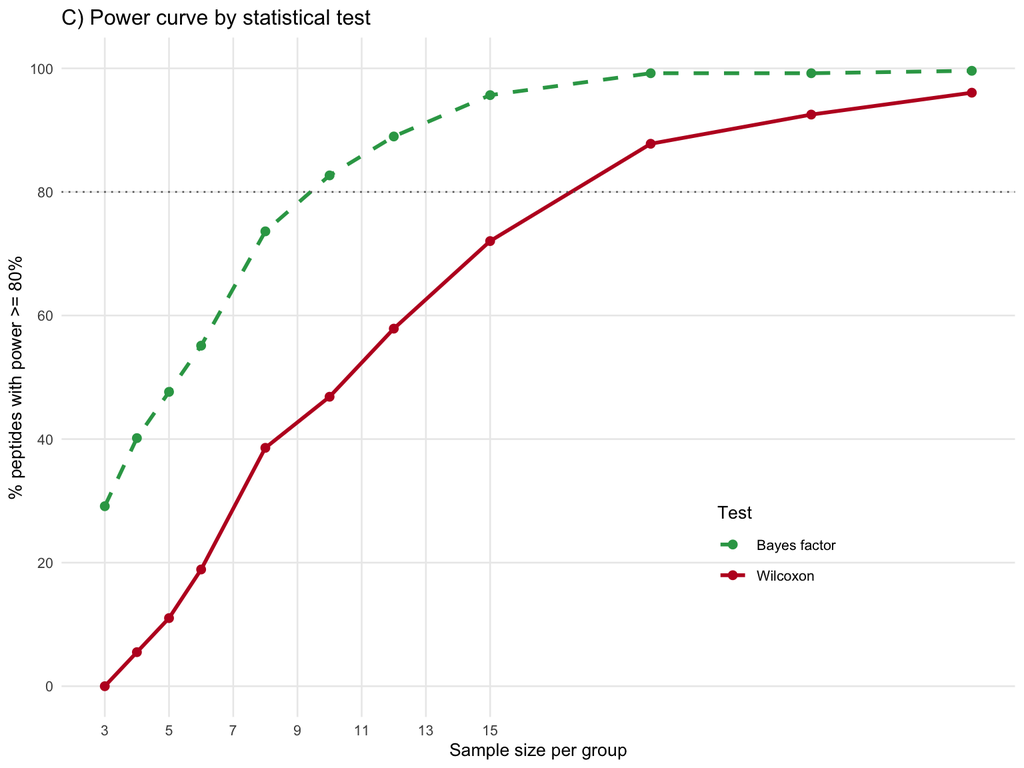

```r
panel_c <- ggplot(curve_data, aes(x = n_per_group, y = pct_powered,
                                   color = test, linetype = test)) +
  geom_line(linewidth = 1) +
  geom_point(size = 2) +
  geom_hline(yintercept = 80, linetype = "dotted", color = "gray40") +
  scale_color_manual(values = c("Wilcoxon" = "#BD0026", "Bayes factor" = "#31A354")) +
  scale_linetype_manual(values = c("Wilcoxon" = "solid", "Bayes factor" = "dashed")) +
  scale_x_continuous(breaks = seq(3, 15, 2)) +
  scale_y_continuous(limits = c(0, 100), breaks = seq(0, 100, 20)) +
  labs(
    x = "Sample size per group",
    y = "% peptides with power >= 80%",
    title = "C) Power curve by statistical test",
    color = "Test",
    linetype = "Test"
  ) +
  theme_minimal(base_size = 10) +
  theme(
    legend.position = c(0.75, 0.25),
    panel.grid.minor = element_blank()
  )

panel_c
```

### 7.4 Panel D: Power heatmap

```r
effect_sizes <- c(1.5, 2, 2.5, 3)
sample_sizes <- 4:12

# Run power analysis for each combination
heatmap_results <- list()

for (es in effect_sizes) {
  for (n in sample_sizes) {
    result <- power_analysis(
      fits,
      effect_size = es,
      n_per_group = n,
      find = "power",
      test = "wilcoxon",
      n_sim = 500
    )

    pct_powered <- mean(result$simulations$peptide_power >= 0.8, na.rm = TRUE) * 100

    heatmap_results[[length(heatmap_results) + 1]] <- tibble(
      effect_size = es,
      n_per_group = n,
      pct_powered = pct_powered
    )
  }
}

heatmap_data <- bind_rows(heatmap_results)
```

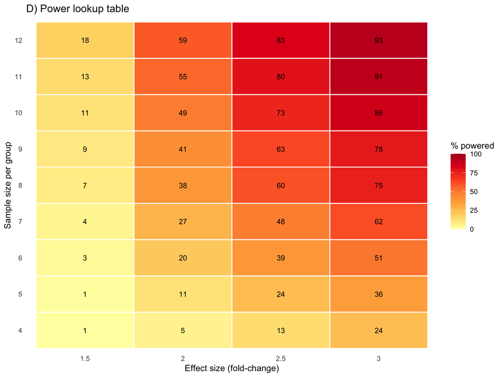

```r
panel_d <- ggplot(heatmap_data, aes(x = factor(effect_size), y = factor(n_per_group),
                                     fill = pct_powered)) +
  geom_tile(color = "white", linewidth = 0.5) +
  geom_text(aes(label = round(pct_powered)), size = 3, color = "black") +
  scale_fill_distiller(palette = "YlOrRd", direction = 1, limits = c(0, 100)) +
  labs(
    x = "Effect size (fold-change)",
    y = "Sample size per group",
    title = "D) Power lookup table",
    fill = "% powered"
  ) +
  theme_minimal(base_size = 10) +
  theme(
    legend.position = "right",
    panel.grid = element_blank()
  )

panel_d
```

### 7.5 Combine into Figure 1

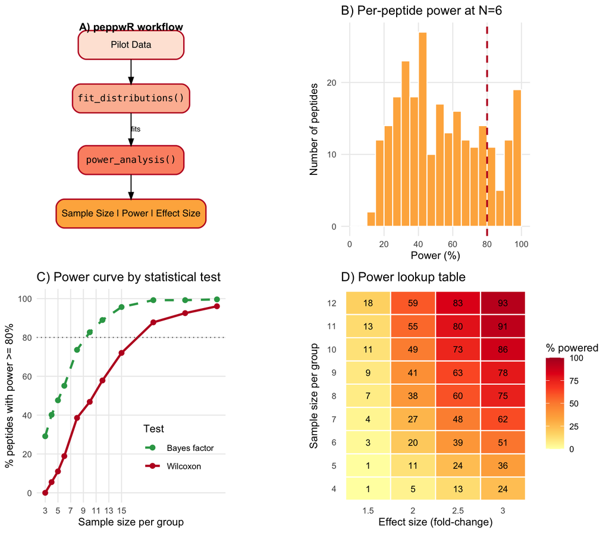

```r
figure_1 <- plot_grid(
  panel_a, panel_b,
  panel_c, panel_d,
  nrow = 2,
  align = "hv"
)

figure_1
```

```r
ggsave("figure_1.png", figure_1, width = 8, height = 7, dpi = 300)
ggsave("figure_1.pdf", figure_1, width = 8, height = 7)

cat("Figure 1 saved to figure_1.png and figure_1.pdf\n
")
```

```
## Figure 1 saved to figure_1.png and figure_1.pdf
```

## 8. Results Summary

```r
results_summary <- tibble(
  Analysis = c(
    "Per-peptide, Wilcoxon",
    "Homogeneous, Wilcoxon",
    "Per-peptide, Bayes factor"
  ),
  `Required N` = c(
    result_primary$answer,
    result_homogeneous$answer,
    result_bayes$answer
  )
)

knitr::kable(results_summary, caption = "Summary of sample size estimates")
```

Summary of sample size estimates

| Analysis | Required N |
| --- | --- |
| Per-peptide, Wilcoxon | 20 |
| Homogeneous, Wilcoxon | 25 |
| Per-peptide, Bayes factor | 10 |

### Key Messages

1. **Per-peptide heterogeneity matters**: Power varies dramatically across peptides. The per-peptide approach (N = 20) gives targeted estimates for achieving 80% power in 80% of peptides.
2. **Naive pooling inflates variance**: The homogeneous approach (N = 25) mixes peptides with different means, artificially inflating variance and potentially leading to different sample size recommendations.
3. **Test choice affects power**: The Bayes factor t-test (N = 10) is 50% more efficient than Wilcoxon (N = 20) when parametric assumptions hold.
4. **Dataset-level MNAR detection**: peppwR detects MNAR patterns by correlating abundance with missingness across peptides, providing diagnostic information about the pilot data.